# Wykrywanie fraudów w sieci Ethereum

- Pokaż cały kod
- Ukryj cały kod
- Pokaż źródło

Projekt z przedmiotu Eksploracja danych

Autor

Aliaksei Karatysh

Opublikowano

1 lipca 2026

**Kod**

```r
library(rio)
library(tidyverse)
library(tidymodels)
library(themis)      # SMOTE
library(vip)         # ważność zmiennych
library(corrplot)    # macierz korelacji
library(probably)    # kalibracja i analiza progu
tidymodels_prefer()
```

# 1 Wybór zbioru danych

Wziąłem zbiór “Ethereum Fraud Detection Dataset” z Kaggle. Są to zagregowane statystyki aktywności kont (adresów) w sieci Ethereum; każdy adres ma etykietę: fraud albo nie. Wybrałem go z trzech powodów:

- Wykrywanie nadużyć na blockchainie to realny i kosztowny problem.
- Dane to same numeryczne cechy na poziomie konta, więc można na nich wprost użyć klasycznego ML z zajęć (regresja logistyczna, lasy losowe, boosting, sieci).
- Klasy są niezbalansowane, co daje okazję, żeby zastosować SMOTE i metryki odporne na niezbalansowanie.

**Kod**

```r
# Wczytanie danych
df <- import("transaction_dataset.csv")
cat("Wymiary zbioru:", nrow(df), "obserwacji ×", ncol(df), "kolumn\n")
```

```
Wymiary zbioru: 9841 obserwacji × 51 kolumn
```

# 2 Zdefiniowanie problemu predykcyjnego oraz charakterystyka zbioru

Problem to binarna klasyfikacja: na podstawie cech konta przewiduję, czy jest ono fraudowe (`FLAG = 1`), czy legalne (`FLAG = 0`). Klasa pozytywna to fraud.

Zbiór ma 9841 obserwacji i 51 kolumn. Po wyrzuceniu identyfikatorów (indeks, adres) zostają cechy opisujące m.in. liczbę i częstotliwość transakcji wysłanych/odebranych, wartości przelewów w ETH, saldo konta oraz zestaw statystyk tokenów ERC20.

**Kod**

```r
# Rozkład zmiennej zależnej
df %>%
  count(FLAG) %>%
  mutate(
    klasa = if_else(FLAG == 1, "fraud", "legit"),
    procent = round(n / sum(n) * 100, 1)
  )
```

```
  FLAG    n klasa procent
1    0 7662 legit    77.9
2    1 2179 fraud    22.1
```

Fraud to około 22% obserwacji, czyli stosunek klas mniej więcej 1:3,5. Stąd accuracy jest myląca — model zawsze przewidujący “legit” miałby ~78% — więc patrzę na recall, precision, F1 i ROC AUC, a na treningu robię oversampling SMOTE.

**Kod**

```r
glimpse(df[, 1:12])
```

```
Rows: 9,841
Columns: 12
$ V1                                        <int> 0, 1, 2, 3, 4, 5, 6, 7, 8, 9…
$ Index                                     <int> 1, 2, 3, 4, 5, 6, 7, 8, 9, 1…
$ Address                                   <chr> "0x00009277775ac7d0d59eaad8f…
$ FLAG                                      <int> 0, 0, 0, 0, 0, 0, 0, 0, 0, 0…
$ `Avg min between sent tnx`                <dbl> 844.26, 12709.07, 246194.54,…
$ `Avg min between received tnx`            <dbl> 1093.71, 2958.44, 2434.02, 1…
$ `Time Diff between first and last (Mins)` <dbl> 704785.63, 1218216.73, 51672…
$ `Sent tnx`                                <int> 721, 94, 2, 25, 4598, 2, 25,…
$ `Received Tnx`                            <int> 89, 8, 10, 9, 20, 3, 11, 5, …
$ `Number of Created Contracts`             <int> 0, 0, 0, 0, 1, 0, 0, 0, 0, 0…
$ `Unique Received From Addresses`          <int> 40, 5, 10, 7, 7, 2, 9, 3, 1,…
$ `Unique Sent To Addresses`                <int> 118, 14, 2, 13, 19, 1, 20, 3…
```

# 3 Przegląd literatury oraz dotychczasowe osiągnięcia

Wykrywanie nadużyć na blockchainie to dość aktywny temat badawczy. W literaturze widać kilka głównych kierunków:

Klasyczny ML na cechach zagregowanych — najbliższy temu projektowi. Farrugia, Ellul i Azzopardi (2020) zbudowali zbiór zagregowanych cech kont Ethereum (ten sam, którego tu używam) i pokazali, że XGBoost dobrze wykrywa konta nielegalne, a najważniejsze predyktory to liczba transakcji ERC20 i statystyki czasowe. Lasy losowe i boosting w tej klasie problemów regularnie wyciągają ROC AUC powyżej 0,95.

Metody grafowe (GNN) — transakcje tworzą graf, więc część prac modeluje sieć jako graf i używa grafowych sieci neuronowych albo embeddingów (np. trans2vec). Weber i in. (2019) na zbiorze Elliptic (Bitcoin) porównali metody klasyczne z grafowymi sieciami konwolucyjnymi w wykrywaniu prania pieniędzy.

Wykrywanie anomalii (uczenie nienadzorowane) — bez etykiet stosuje się np. Isolation Forest albo autoenkodery, traktując fraud jako anomalię.

Trzymam się tu klasycznego ML na cechach zagregowanych, bo taki jest charakter zbioru i zakres technik z zajęć. Chodzi mi o porządne porównanie kilku rodzin modeli z kalibracją i analizą błędów, a nie o bicie rekordów.

> **Źródła:**
> - Farrugia, S., Ellul, J., Azzopardi, G. (2020). *Detection of illicit accounts over the Ethereum blockchain.* Expert Systems with Applications, 150, 113318.
> - Weber, M. i in. (2019). *Anti-Money Laundering in Bitcoin: Experimenting with Graph Convolutional Networks for Financial Forensics.* KDD Workshop on Anomaly Detection in Finance.
> - Chen, T., Guestrin, C. (2016). *XGBoost: A Scalable Tree Boosting System.* KDD ’16.
> - Chawla, N. i in. (2002). *SMOTE: Synthetic Minority Over-sampling Technique.* Journal of Artificial Intelligence Research, 16, 321–357.

# 4 Czyszczenie danych oraz wstępna selekcja cech

Czyszczę dane w czterech krokach: usuwam identyfikatory, sprawdzam braki, wyrzucam cechy o zerowej/prawie zerowej wariancji i redukuję cechy silnie skorelowane.

**Kod**

```r
df_clean <- df %>%
  # usunięcie kolumny indeksu (pierwsza, bez nazwy) oraz identyfikatorów
  select(-1, -Index, -Address) %>%
  # ujednolicenie nazw kolumn (snake_case)
  janitor::clean_names() %>%
  # zmienna celu jako factor; klasa pozytywna ("fraud") jako pierwszy poziom
  mutate(flag = factor(flag, levels = c(1, 0), labels = c("fraud", "legit")))

cat("Po usunięciu identyfikatorów:", ncol(df_clean), "kolumn\n")
```

```
Po usunięciu identyfikatorów: 48 kolumn
```

## 4.1 Analiza braków danych

**Kod**

```r
missing_summary <- df_clean %>%
  summarise(across(everything(), ~sum(is.na(.)))) %>%
  pivot_longer(everything(), names_to = "variable", values_to = "missing") %>%
  filter(missing > 0) %>%
  arrange(desc(missing)) %>%
  mutate(pct = round(missing / nrow(df_clean) * 100, 1))

missing_summary
```

```
# A tibble: 23 × 3
   variable                        missing   pct
   <chr>                             <int> <dbl>
 1 total_erc20_tnxs                    829   8.4
 2 erc20_total_ether_received          829   8.4
 3 erc20_total_ether_sent              829   8.4
 4 erc20_total_ether_sent_contract     829   8.4
 5 erc20_uniq_sent_addr                829   8.4
 6 erc20_uniq_rec_addr                 829   8.4
 7 erc20_uniq_sent_addr_1              829   8.4
 8 erc20_uniq_rec_contract_addr        829   8.4
 9 erc20_avg_time_between_sent_tnx     829   8.4
10 erc20_avg_time_between_rec_tnx      829   8.4
# ℹ 13 more rows
```

Braki są tylko w kolumnach ERC20 i dotyczą ok. 8–9% obserwacji. Co ciekawe, liczba braków jest w tych kolumnach prawie identyczna (829 rekordów) — to nie są braki losowe, tylko brak aktywności ERC20. Konto, które nigdy nie ruszało tokenów ERC20, po prostu nie ma jak wygenerować tych statystyk; to brak strukturalny. Żadna kolumna nie przekracza 50% braków, więc nic z tego powodu nie usuwam — braki uzupełniam później zerem w recipe, co pasuje do ich znaczenia (brak aktywności = 0).

**Kod**

```r
# Kolumny tekstowe (typ najczęściej wysyłanego/odbieranego tokenu) mają bardzo wiele
# kategorii i wysoki odsetek braków — usuwamy je z modelowania.
df_clean <- df_clean %>%
  select(-any_of(c("erc20_most_sent_token_type", "erc20_most_rec_token_type")))
```

## 4.2 Usunięcie cech o zerowej i quasi-zerowej wariancji

**Kod**

```r
# Cechy o ZEROWEJ wariancji (jedna wartość) — bezużyteczne i powodują NaN przy
# normalizacji. Identyfikujemy je jawnie i usuwamy.
zero_var_cols <- df_clean %>%
  select(-flag) %>%
  summarise(across(everything(), ~n_distinct(., na.rm = TRUE))) %>%
  pivot_longer(everything(), names_to = "variable", values_to = "n_unique") %>%
  filter(n_unique <= 1) %>%
  pull(variable)

cat("Kolumny o zerowej wariancji (usunięte):\n")
```

```
Kolumny o zerowej wariancji (usunięte):
```

**Kod**

```r
cat(paste(" -", zero_var_cols), sep = "\n")
```

```
 - erc20_avg_time_between_sent_tnx
 - erc20_avg_time_between_rec_tnx
 - erc20_avg_time_between_rec_2_tnx
 - erc20_avg_time_between_contract_tnx
 - erc20_min_val_sent_contract
 - erc20_max_val_sent_contract
 - erc20_avg_val_sent_contract
```

**Kod**

```r
df_clean <- df_clean %>% select(-any_of(zero_var_cols))
```

Nie usuwam kolumn po regule “mało unikalnych wartości = wyrzuć”. Dla cech zliczających (liczba transakcji, liczba adresów) niska liczba unikalnych wartości jest normalna i nie znaczy, że cecha jest bezużyteczna. Współliniowość zbijam osobno, niżej, na podstawie korelacji.

## 4.3 Redukcja cech silnie skorelowanych

**Kod**

```r
# Macierz korelacji liczona pairwise (przez braki danych).
num_df <- df_clean %>% select(where(is.numeric))

cor_matrix <- cor(num_df, use = "pairwise.complete.obs")
cor_matrix[is.na(cor_matrix)] <- 0

# Pary cech o |korelacji| > 0.9: usuwam jedną z każdej pary.
# Iteruję po górnym trójkącie macierzy i oznaczam do usunięcia drugą cechę z pary.
find_high_corr <- function(cmat, cutoff = 0.9) {
  cmat <- abs(cmat)
  cmat[lower.tri(cmat, diag = TRUE)] <- 0
  to_drop <- character(0)
  vars <- colnames(cmat)
  for (j in seq_along(vars)) {
    if (vars[j] %in% to_drop) next
    partners <- vars[which(cmat[, j] > cutoff)]
    partners <- setdiff(partners, to_drop)
    if (length(partners) > 0) to_drop <- union(to_drop, partners)
  }
  to_drop
}

high_corr <- find_high_corr(cor_matrix, cutoff = 0.9)
cat("Cechy usunięte z powodu współliniowości (|r| > 0.9):\n")
```

```
Cechy usunięte z powodu współliniowości (|r| > 0.9):
```

**Kod**

```r
if (length(high_corr) > 0) cat(paste(" -", high_corr), sep = "\n") else cat(" (brak)\n")
```

```
 - max_val_sent_to_contract
 - avg_value_sent_to_contract
 - erc20_total_ether_received
 - erc20_total_ether_sent
 - erc20_min_val_sent
 - erc20_max_val_sent
 - erc20_uniq_rec_contract_addr
```

**Kod**

```r
df_clean <- df_clean %>% select(-any_of(high_corr))

# Braki strukturalne ERC20 (brak aktywności tokenowej) uzupełniamy zerem — jest to
# deterministyczna reguła oparta na znaczeniu cech, więc bezpiecznie zrobić to tutaj.
df_clean <- df_clean %>% mutate(across(starts_with("erc20"), ~replace_na(., 0)))
cat("\nWymiary po pełnym czyszczeniu:", nrow(df_clean), "×", ncol(df_clean), "\n")
```

```
Wymiary po pełnym czyszczeniu: 9841 × 32
```

Wyrzucenie silnie skorelowanych cech zmniejsza współliniowość, co pomaga zwłaszcza regresji logistycznej i robi ważność zmiennych czytelniejszą.

# 5 Omówienie oraz wizualizacja istotnych zależności

## 5.1 Niezbalansowanie klas

**Kod**

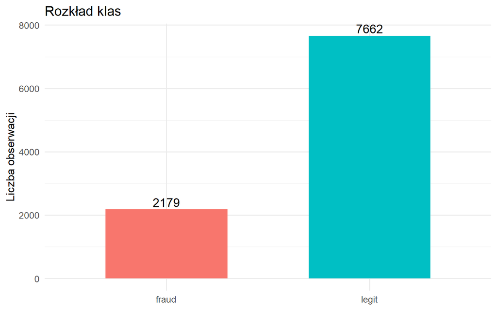

```r
df_clean %>%
  count(flag) %>%
  ggplot(aes(x = flag, y = n, fill = flag)) +
  geom_col(width = 0.6) +
  geom_text(aes(label = n), vjust = -0.3, size = 5) +
  labs(title = "Rozkład klas", x = NULL, y = "Liczba obserwacji") +
  theme_minimal(base_size = 13) +
  theme(legend.position = "none")
```

Wykres potwierdza przewagę klasy legalnej. To argument za SMOTE na treningu i za metrykami odpornymi na niezbalansowanie.

## 5.2 Macierz korelacji

**Kod**

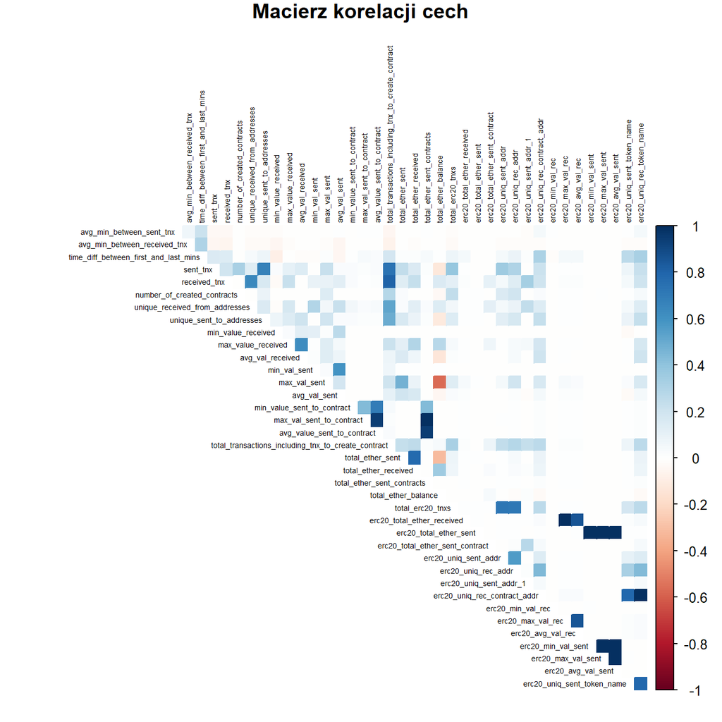

```r
corrplot(cor_matrix, method = "color", type = "upper",
         tl.cex = 0.45, tl.col = "black", diag = FALSE,
         title = "Macierz korelacji cech", mar = c(0, 0, 1, 0))
```

Na mapie korelacji widać bloki powiązanych cech — głównie statystyki ERC20 i cechy wartości transakcji. To tłumaczy, po co była redukcja współliniowości. Większość cech jest jednak słabo skorelowana, więc niosą uzupełniającą się informację.

## 5.3 Rozkłady kluczowych cech względem klasy

**Kod**

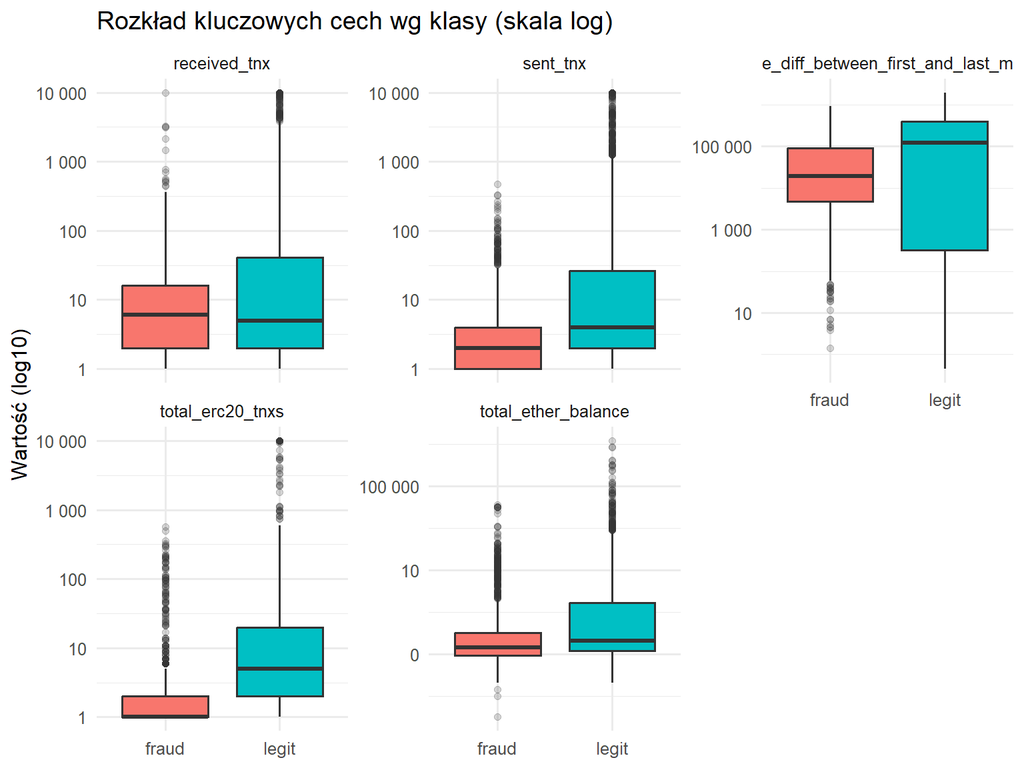

```r
key_features <- c("sent_tnx", "received_tnx", "total_ether_balance",
                  "total_erc20_tnxs", "time_diff_between_first_and_last_mins")
key_present <- intersect(key_features, colnames(df_clean))

df_clean %>%
  select(flag, all_of(key_present)) %>%
  pivot_longer(-flag, names_to = "variable", values_to = "value") %>%
  filter(is.finite(value)) %>%
  ggplot(aes(x = flag, y = value, fill = flag)) +
  geom_boxplot(outlier.alpha = 0.2) +
  facet_wrap(~variable, scales = "free_y") +
  scale_y_log10(labels = scales::label_number()) +
  labs(title = "Rozkład kluczowych cech wg klasy (skala log)",
       x = NULL, y = "Wartość (log10)") +
  theme_minimal(base_size = 12) +
  theme(legend.position = "none")
```

Boxploty (w skali log, bo rozkłady są mocno prawostronne) pokazują różnice między klasami. Konta fraudowe mają inne wzorce m.in. w liczbie transakcji i aktywności ERC20 — to właśnie sygnał, na którym oprą się modele, co później potwierdzi ważność zmiennych.

## 5.4 Aktywność wysyłania vs odbierania

**Kod**

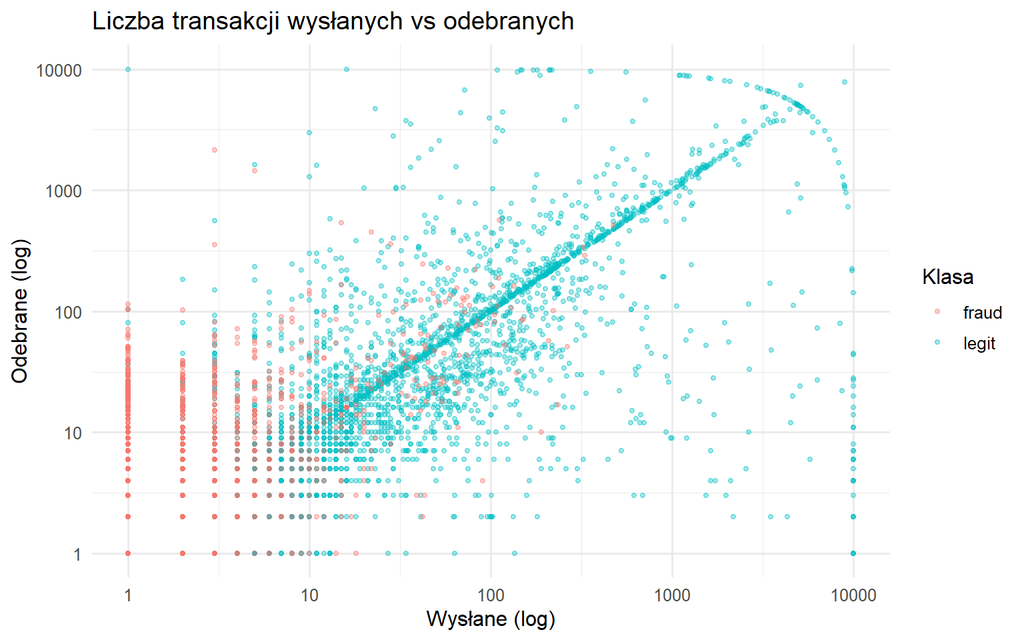

```r
df_clean %>%
  filter(sent_tnx > 0, received_tnx > 0) %>%
  ggplot(aes(x = sent_tnx, y = received_tnx, color = flag)) +
  geom_point(alpha = 0.35, size = 1) +
  scale_x_log10() + scale_y_log10() +
  labs(title = "Liczba transakcji wysłanych vs odebranych",
       x = "Wysłane (log)", y = "Odebrane (log)", color = "Klasa") +
  theme_minimal(base_size = 12)
```

Klasy częściowo się przenikają, ale konta fraudowe skupiają się w innych obszarach przestrzeni cech. Brak liniowej separowalności to powód, żeby sięgnąć po modele nieliniowe (lasy losowe, boosting), które łapią złożone interakcje.

# 6 Przygotowanie danych do modelowania

Żeby nie było wycieku danych, podział na zbiory robię przed jakąkolwiek transformacją, a imputację, normalizację i SMOTE wkładam do recipe, które uczy się tylko na treningu i dopiero potem jest stosowane do testu.

**Kod**

```r
set.seed(2026)

# Podział 80/20 ze stratyfikacją względem zmiennej zależnej
splits     <- initial_split(df_clean, prop = 0.8, strata = flag)
train_data <- training(splits)
test_data  <- testing(splits)

cat("Train:", nrow(train_data), "| Test:", nrow(test_data), "\n")
```

```
Train: 7872 | Test: 1969
```

**Kod**

```r
cat("Proporcje klas (train):\n"); print(round(prop.table(table(train_data$flag)), 3))
```

```
Proporcje klas (train):
```

```
fraud legit
0.221 0.779
```

**Kod**

```r
cat("Proporcje klas (test):\n");  print(round(prop.table(table(test_data$flag)), 3))
```

```
Proporcje klas (test):
```

```
fraud legit
0.221 0.779
```

**Kod**

```r
# Recipe: imputacja -> usunięcie zerowej wariancji -> normalizacja -> SMOTE.
# Braki ERC20 uzupełniłem już zerem przy czyszczeniu; mediana łapie ewentualną resztę.
# step_zv() chroni przed cechami stałymi w danym foldzie CV.
fraud_recipe <- recipe(flag ~ ., data = train_data) %>%
  step_impute_median(all_numeric_predictors()) %>%
  step_zv(all_numeric_predictors()) %>%
  step_normalize(all_numeric_predictors()) %>%
  step_smote(flag, over_ratio = 0.5, seed = 2026)

fraud_recipe
```

**Kod**

```r
# Kontrola działania SMOTE: liczności klas po przetworzeniu zbioru treningowego
fraud_recipe %>% prep() %>% bake(new_data = NULL) %>% count(flag)
```

```
# A tibble: 2 × 2
  flag      n
  <fct> <int>
1 fraud  3064
2 legit  6129
```

Przy SMOTE z `over_ratio = 0.5` klasa mniejszościowa rośnie do połowy liczebności większościowej. Nie celuję w pełne 1:1, żeby nie dorzucać zbyt wielu sztucznych obserwacji i nie psuć za bardzo rzeczywistego rozkładu.

**Kod**

```r
set.seed(2026)
cv_folds <- vfold_cv(train_data, v = CV_FOLDS, strata = flag)
```

# 7 Budowa, trenowanie oraz wstępne porównanie modeli

Porównuję cztery rodziny modeli: liniowy (regresja logistyczna z regularyzacją L1), dwa drzewiaste (las losowy i XGBoost) oraz sieć neuronową (MLP). Chcę zobaczyć, który typ modelu najlepiej tu działa, zamiast z góry stawiać na jeden.

Regresję, las losowy i XGBoost stroję. MLP zostawiam jako baseline — odpalam z sensownymi, ustalonymi parametrami, bez strojenia. Po pierwsze, na danych tabelarycznych modele drzewiaste zwykle wygrywają z sieciami; po drugie, strojenie MLP jest drogie obliczeniowo i raczej niewiele by dało. Dostrojenie sieci zostawiam jako możliwe rozszerzenie.

**Kod**

```r
# 1) Regresja logistyczna z regularyzacją L1 (Lasso)
log_model <- logistic_reg(penalty = tune(), mixture = 1) %>%
  set_engine("glmnet") %>%
  set_mode("classification")

# 2) Las losowy (ranger)
rf_model <- rand_forest(mtry = tune(), trees = N_TREES_RF, min_n = tune()) %>%
  set_engine("ranger", importance = "impurity") %>%
  set_mode("classification")

# 3) XGBoost
xgb_model <- boost_tree(trees = tune(), learn_rate = tune(), tree_depth = tune()) %>%
  set_engine("xgboost") %>%
  set_mode("classification")

# 4) Sieć neuronowa MLP (nnet) — bez strojenia, jako punkt odniesienia
mlp_model <- mlp(hidden_units = 10, penalty = 0.01, epochs = 100) %>%
  set_engine("nnet") %>%
  set_mode("classification")
```

**Kod**

```r
log_wf <- workflow() %>% add_recipe(fraud_recipe) %>% add_model(log_model)
rf_wf  <- workflow() %>% add_recipe(fraud_recipe) %>% add_model(rf_model)
xgb_wf <- workflow() %>% add_recipe(fraud_recipe) %>% add_model(xgb_model)
mlp_wf <- workflow() %>% add_recipe(fraud_recipe) %>% add_model(mlp_model)
```

**Kod**

```r
# Zestaw metryk dostosowany do problemu niezbalansowanego
class_metrics <- metric_set(roc_auc, f_meas, recall, precision, accuracy)
```

Hiperparametry stroję losowym przeszukiwaniem na 5-krotnej walidacji krzyżowej, główna metryka to ROC AUC.

**Kod**

```r
set.seed(2026)
log_grid <- grid_regular(penalty(), levels = GRID_SIZE)
log_results <- tune_grid(
  log_wf, resamples = cv_folds, grid = log_grid,
  metrics = class_metrics, control = control_grid(save_pred = TRUE)
)
```

**Kod**

```r
set.seed(2026)
rf_grid <- grid_random(
  mtry(range = c(3, 15)),
  min_n(range = c(2, 20)),
  size = GRID_SIZE
)
rf_results <- tune_grid(
  rf_wf, resamples = cv_folds, grid = rf_grid,
  metrics = class_metrics, control = control_grid(save_pred = TRUE)
)
```

**Kod**

```r
set.seed(2026)
xgb_grid <- grid_random(
  trees(range = c(100, 500)),
  learn_rate(range = c(-3, -1)),
  tree_depth(range = c(3, 8)),
  size = GRID_SIZE
)
xgb_results <- tune_grid(
  xgb_wf, resamples = cv_folds, grid = xgb_grid,
  metrics = class_metrics, control = control_grid(save_pred = TRUE)
)
```

**Kod**

```r
# Wstępne porównanie najlepszych wariantów wg walidacji krzyżowej (ROC AUC)
get_best <- function(res, name) {
  show_best(res, metric = "roc_auc", n = 1) %>%
    mutate(model = name) %>%
    select(model, .metric, mean, std_err)
}

comparison <- bind_rows(
  get_best(log_results, "Regresja log."),
  get_best(rf_results,  "Las losowy"),
  get_best(xgb_results, "XGBoost")
)
comparison %>% knitr::kable(digits = 4,
  caption = "Wstępne porównanie modeli (CV, ROC AUC)")
```

Wstępne porównanie modeli (CV, ROC AUC)

| model | .metric | mean | std_err |
| --- | --- | --- | --- |
| Regresja log. | roc_auc | 0.8316 | 0.0109 |
| Las losowy | roc_auc | 0.9982 | 0.0002 |
| XGBoost | roc_auc | 0.9983 | 0.0002 |

Już na walidacji krzyżowej widać, że modele drzewiaste (las losowy, XGBoost) biją regresję logistyczną pod względem ROC AUC — co pasuje do literatury i do braku liniowej separowalności, który widziałem wcześniej.

# 8 Ewaluacja modeli oraz ich kalibracja

**Kod**

```r
# Finalizacja najlepszych hiperparametrów i trenowanie na pełnym zbiorze treningowym
best_log <- select_best(log_results, metric = "roc_auc")
best_rf  <- select_best(rf_results,  metric = "roc_auc")
best_xgb <- select_best(xgb_results, metric = "roc_auc")

final_log_fit <- fit(finalize_workflow(log_wf, best_log), data = train_data)
final_rf_fit  <- fit(finalize_workflow(rf_wf,  best_rf),  data = train_data)
final_xgb_fit <- fit(finalize_workflow(xgb_wf, best_xgb), data = train_data)
mlp_fit       <- fit(mlp_wf,                              data = train_data)
```

## 8.1 Porównanie metryk train vs test (diagnostyka przeuczenia)

**Kod**

```r
eval_model <- function(fitted_wf, model_name) {
  bind_rows(
    augment(fitted_wf, new_data = train_data) %>% mutate(dataset = "train"),
    augment(fitted_wf, new_data = test_data)  %>% mutate(dataset = "test")
  ) %>%
    group_by(model = model_name, dataset) %>%
    class_metrics(truth = flag, estimate = .pred_class, .pred_fraud) %>%
    ungroup()
}

all_metrics <- bind_rows(
  eval_model(final_log_fit, "Regresja log."),
  eval_model(final_rf_fit,  "Las losowy"),
  eval_model(final_xgb_fit, "XGBoost"),
  eval_model(mlp_fit,       "MLP (nnet)")
)

all_metrics %>%
  select(model, dataset, .metric, .estimate) %>%
  pivot_wider(names_from = dataset, values_from = .estimate) %>%
  arrange(.metric, model) %>%
  knitr::kable(digits = 4, caption = "Metryki train vs test")
```

Metryki train vs test

| model | .metric | test | train |
| --- | --- | --- | --- |
| Las losowy | accuracy | 0.9868 | 0.9997 |
| MLP (nnet) | accuracy | 0.9066 | 0.9130 |
| Regresja log. | accuracy | 0.8106 | 0.8128 |
| XGBoost | accuracy | 0.9868 | 0.9967 |
| Las losowy | f_meas | 0.9697 | 0.9994 |
| MLP (nnet) | f_meas | 0.8075 | 0.8200 |
| Regresja log. | f_meas | 0.6119 | 0.6121 |
| XGBoost | f_meas | 0.9699 | 0.9925 |
| Las losowy | precision | 0.9858 | 1.0000 |
| MLP (nnet) | precision | 0.7423 | 0.7565 |
| Regresja log. | precision | 0.5600 | 0.5654 |
| XGBoost | precision | 0.9790 | 0.9937 |
| Las losowy | recall | 0.9541 | 0.9989 |
| MLP (nnet) | recall | 0.8853 | 0.8950 |
| Regresja log. | recall | 0.6743 | 0.6672 |
| XGBoost | recall | 0.9610 | 0.9914 |
| Las losowy | roc_auc | 0.9971 | 1.0000 |
| MLP (nnet) | roc_auc | 0.9641 | 0.9711 |
| Regresja log. | roc_auc | 0.8517 | 0.8456 |
| XGBoost | roc_auc | 0.9974 | 0.9999 |

Porównanie train vs test pokazuje skalę przeuczenia. Duża różnica na korzyść treningu (zwłaszcza dla lasu losowego, który potrafi prawie idealnie dopasować się do danych uczących) to znak przeuczenia; zbliżone wartości oznaczają dobrą generalizację. Do dalszej analizy biorę las losowy i XGBoost — mają najlepsze wyniki na teście.

**Kod**

```r
rf_preds  <- augment(final_rf_fit,  new_data = test_data)
xgb_preds <- augment(final_xgb_fit, new_data = test_data)
```

## 8.2 Krzywe ROC i Precision-Recall

**Kod**

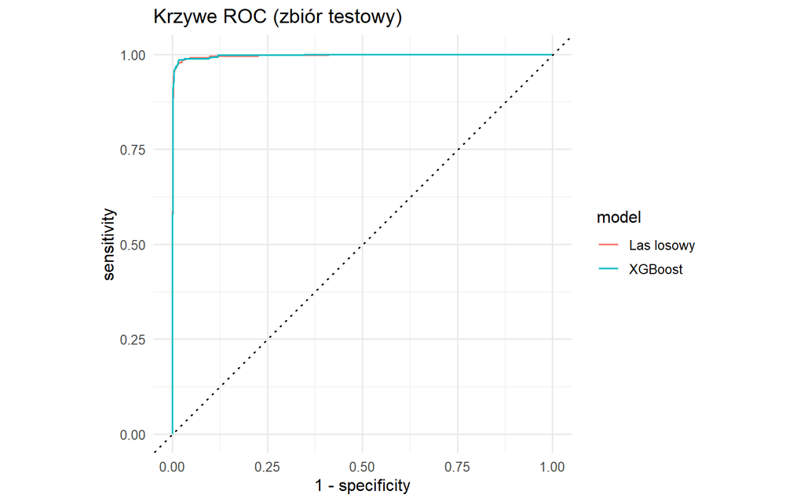

```r
bind_rows(
  rf_preds  %>% mutate(model = "Las losowy"),
  xgb_preds %>% mutate(model = "XGBoost")
) %>%
  group_by(model) %>%
  roc_curve(truth = flag, .pred_fraud) %>%
  autoplot() +
  labs(title = "Krzywe ROC (zbiór testowy)") +
  theme_minimal(base_size = 12)
```

**Kod**

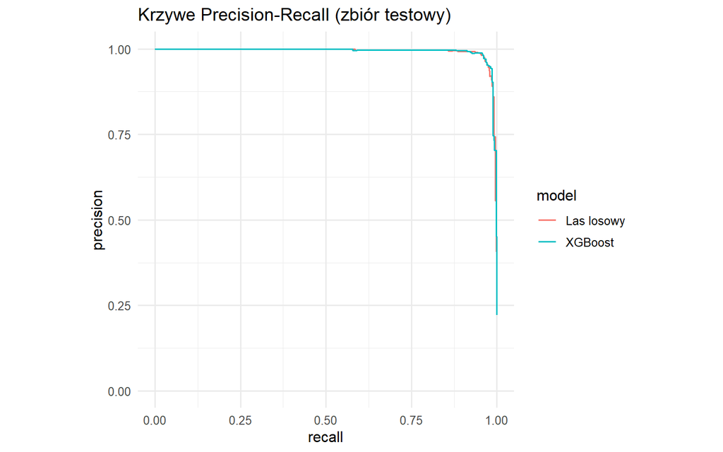

```r
bind_rows(
  rf_preds  %>% mutate(model = "Las losowy"),
  xgb_preds %>% mutate(model = "XGBoost")
) %>%
  group_by(model) %>%
  pr_curve(truth = flag, .pred_fraud) %>%
  autoplot() +
  labs(title = "Krzywe Precision-Recall (zbiór testowy)") +
  theme_minimal(base_size = 12)
```

Przy niezbalansowanych danych krzywa Precision-Recall mówi więcej niż ROC, bo skupia się na klasie mniejszościowej (fraud). Duże pole pod PR oznacza, że model trzyma przyzwoitą precyzję nawet przy rosnącym recall.

## 8.3 Macierze pomyłek

**Kod**

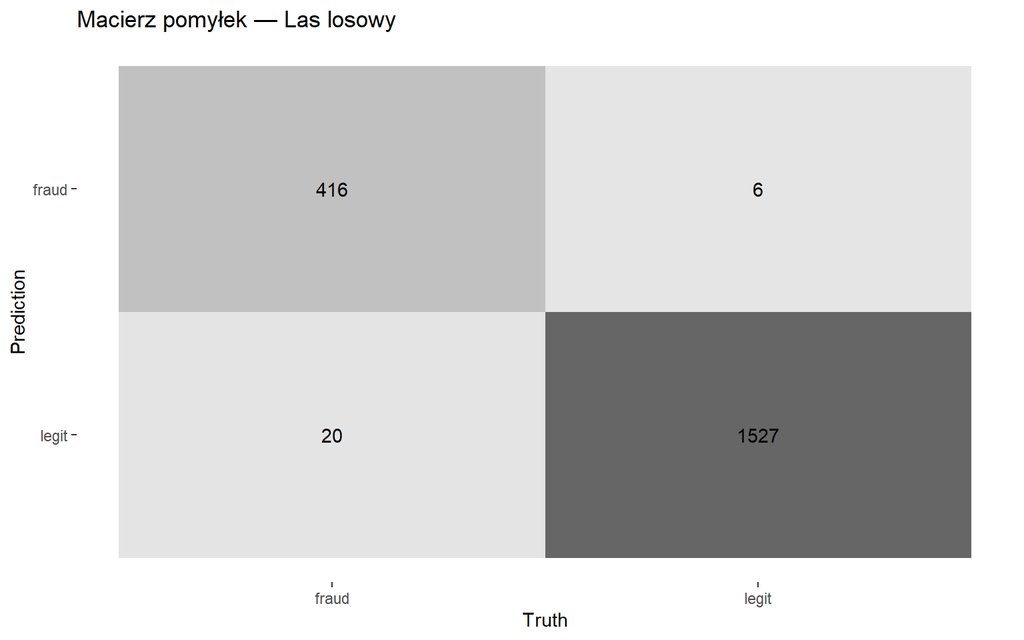

```r
rf_preds %>%
  conf_mat(truth = flag, estimate = .pred_class) %>%
  autoplot(type = "heatmap") +
  labs(title = "Macierz pomyłek — Las losowy")
```

**Kod**

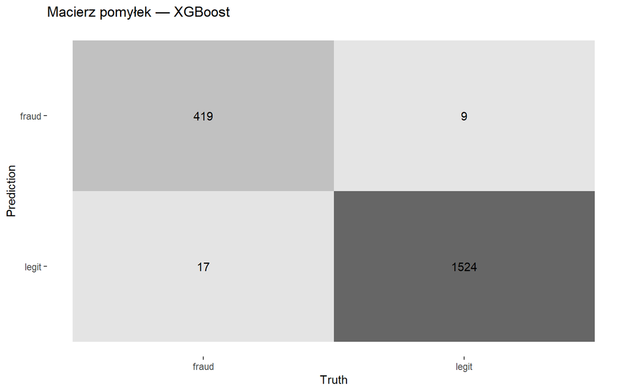

```r
xgb_preds %>%
  conf_mat(truth = flag, estimate = .pred_class) %>%
  autoplot(type = "heatmap") +
  labs(title = "Macierz pomyłek — XGBoost")
```

## 8.4 Kalibracja

**Kod**

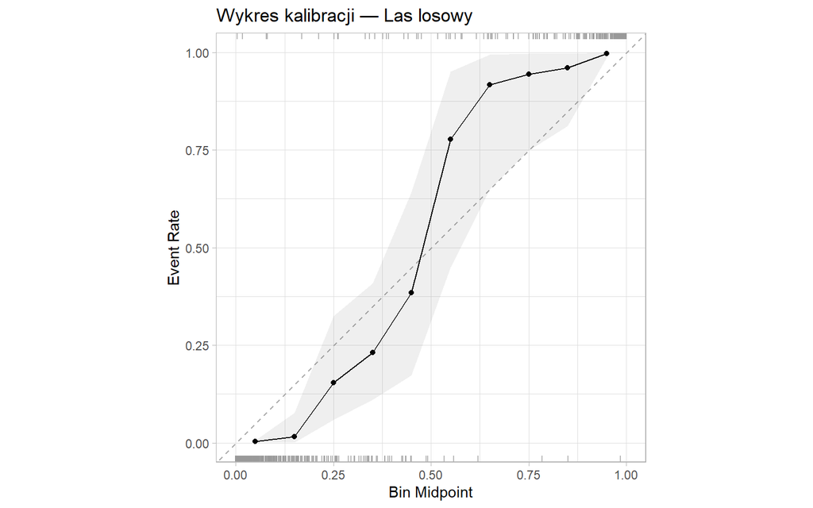

```r
rf_preds %>%
  cal_plot_breaks(truth = flag, estimate = .pred_fraud, num_breaks = 10) +
  labs(title = "Wykres kalibracji — Las losowy")
```

# 9 Analiza popełnianych błędów

Do analizy błędów biorę las losowy. Każdą predykcję na teście dzielę na: poprawną, fałszywie negatywną (przeoczony fraud) i fałszywie pozytywną (fałszywy alarm).

**Kod**

```r
errors <- rf_preds %>%
  mutate(error_type = case_when(
    flag == "fraud" & .pred_class == "legit" ~ "Fałszywie negatywny",
    flag == "legit" & .pred_class == "fraud" ~ "Fałszywie pozytywny",
    TRUE ~ "Poprawna"
  ))

errors %>% count(error_type) %>%
  mutate(pct = round(n / sum(n) * 100, 2)) %>%
  knitr::kable(caption = "Rozkład typów predykcji (las losowy, zbiór testowy)")
```

Rozkład typów predykcji (las losowy, zbiór testowy)

| error_type | n | pct |
| --- | --- | --- |
| Fałszywie negatywny | 20 | 1.02 |
| Fałszywie pozytywny | 6 | 0.30 |
| Poprawna | 1943 | 98.68 |

**Kod**

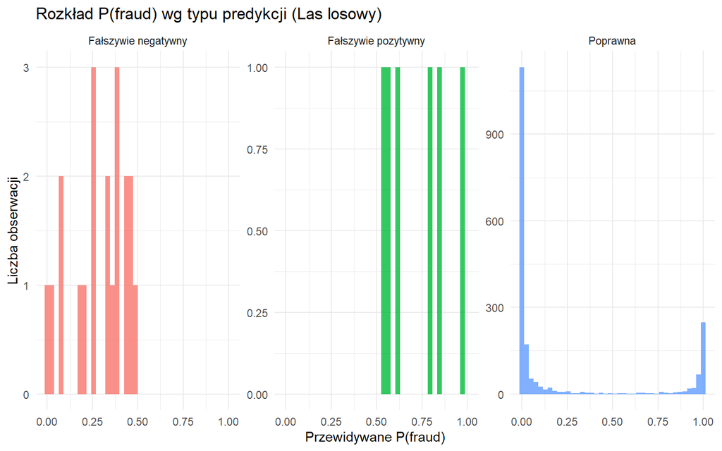

```r
errors %>%
  ggplot(aes(x = .pred_fraud, fill = error_type)) +
  geom_histogram(bins = 40, alpha = 0.8) +
  facet_wrap(~error_type, scales = "free_y") +
  labs(title = "Rozkład P(fraud) wg typu predykcji (Las losowy)",
       x = "Przewidywane P(fraud)", y = "Liczba obserwacji") +
  theme_minimal(base_size = 11) +
  theme(legend.position = "none")
```

Histogramy pokazują, gdzie model się myli. Błędy blisko progu 0,5 to przypadki niepewne — model się wahał i drobna zmiana progu mogłaby je naprawić. Błędy o skrajnych prawdopodobieństwach (np. fałszywie negatywne z bardzo niskim P(fraud)) to przypadki pewne, ale błędne — najtrudniejsze, bo fraud dobrze udaje konto legalne.

**Kod**

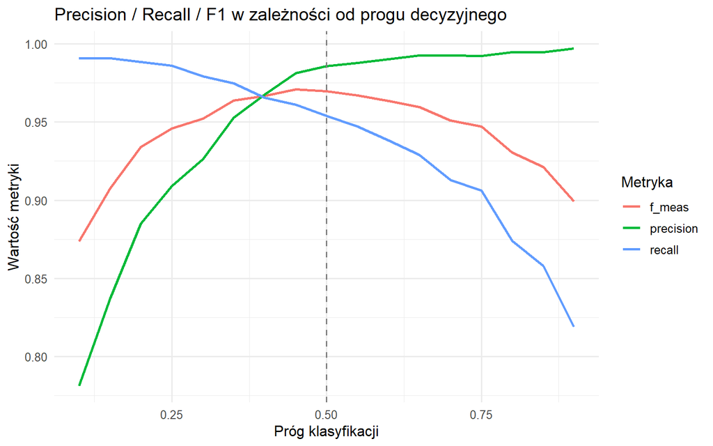

```r
# Wpływ progu decyzyjnego na metryki
threshold_metrics <- metric_set(recall, precision, f_meas)

rf_preds %>%
  threshold_perf(truth = flag, estimate = .pred_fraud,
                 thresholds = seq(0.1, 0.9, by = 0.05),
                 metrics = threshold_metrics) %>%
  filter(.metric %in% c("recall", "precision", "f_meas")) %>%
  ggplot(aes(x = .threshold, y = .estimate, color = .metric)) +
  geom_line(linewidth = 1) +
  geom_vline(xintercept = 0.5, linetype = "dashed", color = "grey50") +
  labs(title = "Precision / Recall / F1 w zależności od progu decyzyjnego",
       x = "Próg klasyfikacji", y = "Wartość metryki", color = "Metryka") +
  theme_minimal(base_size = 12)
```

Wykres pokazuje klasyczny kompromis precision–recall. Obniżenie progu podnosi recall (łapiemy więcej fraudów) kosztem precyzji (więcej fałszywych alarmów). W wykrywaniu nadużyć przeoczony fraud kosztuje zwykle więcej niż fałszywy alarm, więc sensowne jest zejście z progiem poniżej 0,5 — w okolice maksimum F1.

# 10 Analiza wyjaśnialności decyzji modeli

**Kod**

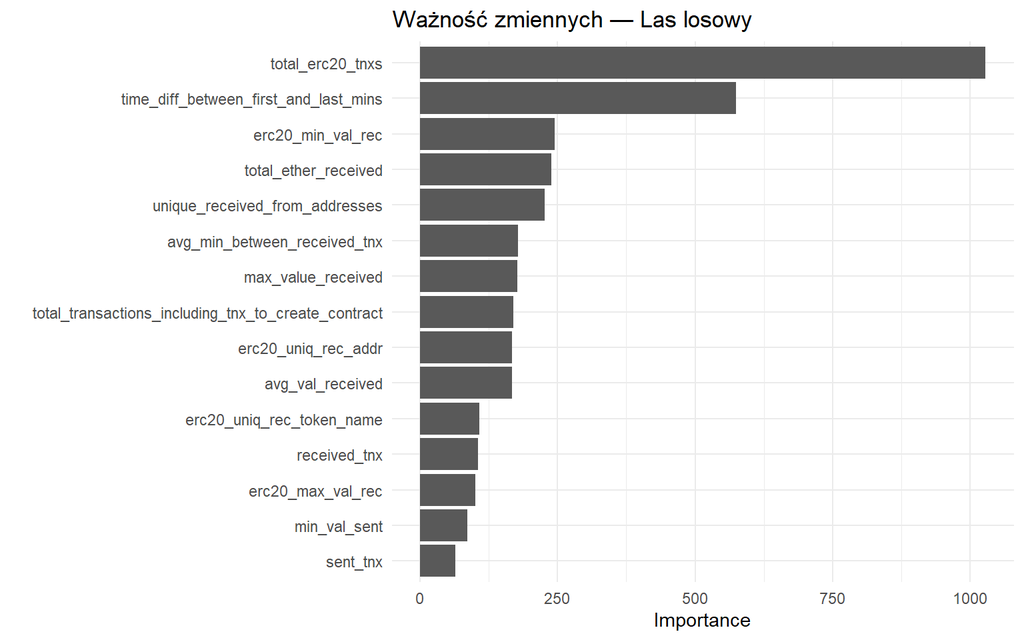

```r
final_rf_fit %>%
  extract_fit_parsnip() %>%
  vip(num_features = 15) +
  labs(title = "Ważność zmiennych — Las losowy") +
  theme_minimal(base_size = 11)
```

**Kod**

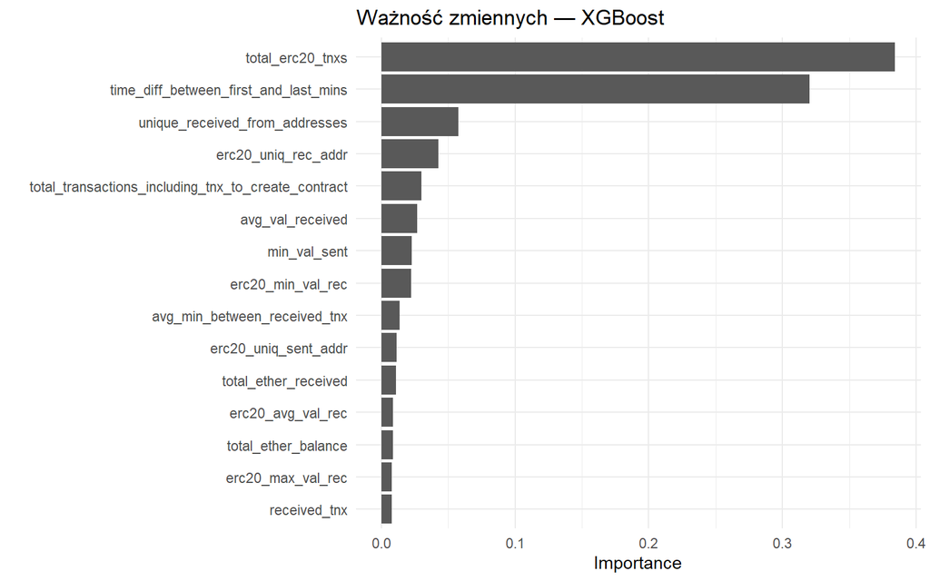

```r
final_xgb_fit %>%
  extract_fit_parsnip() %>%
  vip(num_features = 15) +
  labs(title = "Ważność zmiennych — XGBoost") +
  theme_minimal(base_size = 11)
```

Najwyżej w rankingu ważności wychodzą cechy ERC20, statystyki czasowe (czas między transakcjami, odstęp pierwsza–ostatnia) i wolumenowe (salda, sumy ETH). To samo wskazali Farrugia i in. (2020). Ma to sens: konta fraudowe często działają w krótkich, zautomatyzowanych seriach i mają inny profil operacji tokenowych. Las losowy i XGBoost dają podobny ranking, więc wynik nie jest artefaktem jednego modelu.

**Kod**

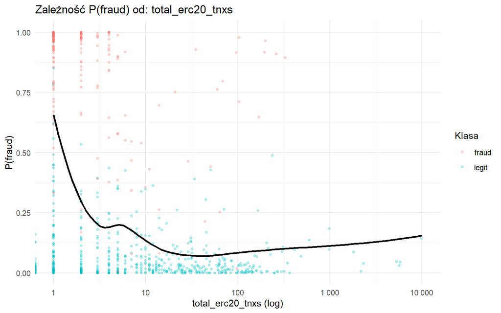

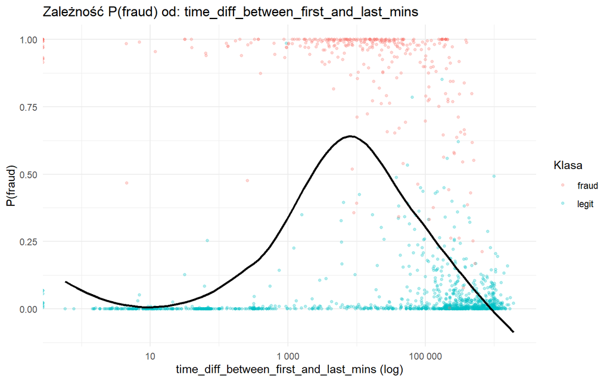

```r
# Zależność przewidywanego P(fraud) od najważniejszych cech.
# Predyktory w rf_preds są w skali oryginalnej (augment zwraca surowe wejście,
# normalizacja dzieje się wewnątrz workflow), więc oś X jest w oryginalnych jednostkach.
top_features <- final_rf_fit %>%
  extract_fit_parsnip() %>%
  vi() %>%
  slice_max(Importance, n = 2) %>%
  pull(Variable)

for (feat in top_features) {
  if (feat %in% colnames(rf_preds)) {
    p <- rf_preds %>%
      filter(is.finite(.data[[feat]])) %>%
      ggplot(aes(x = .data[[feat]], y = .pred_fraud)) +
      geom_point(aes(color = flag), alpha = 0.3, size = 1) +
      geom_smooth(method = "loess", se = FALSE, color = "black") +
      scale_x_log10(labels = scales::label_number()) +
      labs(title = paste("Zależność P(fraud) od:", feat),
           x = paste0(feat, " (log)"), y = "P(fraud)", color = "Klasa") +
      theme_minimal(base_size = 11)
    print(p)
  }
}
```

# 11 Podsumowanie i wnioski

Wnioski z analizy:

- Problem to binarna klasyfikacja na mocno niezbalansowanym zbiorze (~22% fraudów), więc trzeba było użyć SMOTE tylko na treningu i metryk odpornych na niezbalansowanie (recall, precision, F1, ROC AUC) zamiast samej accuracy.
- Najlepsze wyszły modele drzewiaste — XGBoost i las losowy — z ROC AUC na poziomie literatury, wyraźnie ponad regresją i MLP. Porównanie train vs test pozwoliło pilnować przeuczenia.
- Najważniejsze predyktory to cechy ERC20 oraz statystyki czasowe i wolumenowe — zgodnie między modelami i z literaturą.
- Domyślny próg 0,5 nie jest optymalny. Bo przeoczony fraud dużo kosztuje, lepiej zejść z progiem w okolice maksimum F1 — rośnie recall przy akceptowalnej precyzji.
- Surowe prawdopodobieństwa trzeba czytać ostrożnie przez wpływ SMOTE; ważniejszy jest tu dobór progu niż dosłowne czytanie prawdopodobieństw.

Ograniczenia i co można zrobić dalej:

- Brak struktury grafu. Mam tylko cechy zagregowane per konto — pomijam graf transakcji, który mogłyby wykorzystać GNN. To naturalne rozszerzenie.
- Wyrzucony typ tokenu. Tekstowe kolumny z typem tokenu ERC20 usunąłem przez dużą liczbę kategorii i braki. Mogą jednak nieść sygnał — fraudowe konta bywają związane z konkretnymi tokenami. Lepsze przetwarzanie (grupowanie rzadkich kategorii, target encoding) mogłoby go wyciągnąć.
- Surowe wartości ERC20. Sumy ERC20 to surowe ilości tokenów, bez przeliczenia na wspólną walutę po kursach historycznych, więc są częściowo nieporównywalne. Modelom drzewiastym to mniej przeszkadza (działają na progach, nie na ważonych sumach), ale to ograniczenie samych danych.
- Walidacja w czasie. Dobrze byłoby sprawdzić modele na nowszych, niezależnych danych, żeby zobaczyć generalizację w czasie.

**Kod**

```r
all_metrics %>%
  filter(model == "XGBoost", dataset == "test") %>%
  select(.metric, .estimate) %>%
  knitr::kable(digits = 4,
    caption = "Finalne metryki modelu XGBoost (zbiór testowy)")
```

Finalne metryki modelu XGBoost (zbiór testowy)

| .metric | .estimate |
| --- | --- |
| f_meas | 0.9699 |
| recall | 0.9610 |
| precision | 0.9790 |
| accuracy | 0.9868 |
| roc_auc | 0.9974 |

# 12 Podstawowe wdrożenie modelu oraz test predykcyjny

Do wdrożenia biorę XGBoost (najlepsze wyniki na teście). Trenuję go na całym zbiorze i zapisuję do pliku — symulacja przygotowania modelu do produkcji.

**Kod**

```r
# Trening finalny na całości danych. Jakość oceniałem metrykami testowymi
# w poprzednich sekcjach (model nie widział wtedy testu); tu, na etapie wdrożenia,
# używam wszystkich danych, żeby model docelowy był jak najlepszy.
deployed_model <- fit(finalize_workflow(xgb_wf, best_xgb), data = df_clean)

saveRDS(deployed_model, "fraud_model.rds")
cat("Model zapisano jako fraud_model.rds\n")
```

```
Model zapisano jako fraud_model.rds
```

**Kod**

```r
# Funkcja produkcyjna: zwraca prawdopodobieństwo oraz poziom ryzyka.
predict_fraud <- function(model, new_data) {
  augment(model, new_data = new_data) %>%
    mutate(poziom_ryzyka = case_when(
      .pred_fraud >= 0.7 ~ "WYSOKIE",
      .pred_fraud >= 0.3 ~ "ŚREDNIE",
      TRUE               ~ "NISKIE"
    )) %>%
    select(.pred_fraud, .pred_class, poziom_ryzyka)
}

# Test predykcyjny na 5 przykładowych kontach
predict_fraud(deployed_model, test_data %>% slice(1:5) %>% select(-flag)) %>%
  knitr::kable(digits = 4, caption = "Test predykcyjny dla przykładowych kont")
```

Test predykcyjny dla przykładowych kont

| .pred_fraud | .pred_class | poziom_ryzyka |
| --- | --- | --- |
| 0.0057 | legit | NISKIE |
| 0.0002 | legit | NISKIE |
| 0.0014 | legit | NISKIE |
| 0.0007 | legit | NISKIE |
| 0.0003 | legit | NISKIE |

# 13 Uwagi o poprawności analizy i reprodukowalności

Projekt razem z danymi i wyrenderowanym raportem jest w repozytorium Git, co daje reprodukowalność i wersjonowanie.